# Predicting Music Genres

Samuel Kuenti

12 5 2022

## Abstract

*The aim of this project was to predict the music genre of a song based on a number of features of the song. In order to achieve this, a knn-model was compared to a random forest approach. It was expected that while the random forest model would perform reasonably well, the knn-model would be overwhelmed with the number of predictors used. This was confirmed by testing and comparing the models on actual data. Both models could not be optimised fully due to limitations imposed by long computation times.*

## Introduction

The aim of this project is to develop a machine learning algorithm to predict the genre of a song based on a number of attributes. Such an algorithm could support the automatic organisation of a collection of digital music.

The project guidelines ask for at least two different modeling approaches to be compared side by side. As will be discussed below, the data in this case provides multiple predictors. Based on theory, simpler modelling approaches like k-nearest neighbors should suffer when too many predictors are involved. In order to explore this theoretical caveat, a k-nearest-neighbor model will be compared to a random forest approach, which should deal better with a larger number of inputs.

## Analysis

### Data Preparation

#### Obtaining Data

This project is based on [data](https://www.kaggle.com/datasets/vicsuperman/prediction-of-music-genre?resource=download) compiled into a CSV file by Gaoyuan. The dataset is available from the public kaggle data repository. Due to issues with implementing kaggle’s authentication process in R, the data file was copied to this project’s GitHub repository and is loaded from there.

### Initial data inspection

The following table shows what kind of information the dataset contains.

Variables in the dataset

instance_id

artist_name

track_name

popularity

acousticness

danceability

duration_ms

energy

instrumentalness

key

liveness

loudness

mode

speechiness

tempo

obtained_date

valence

music_genre

#### Data cleaning

An initial look at the raw data reveals that some songs seem to have incomplete information (e.g. tempo = ?, or a duration of -1ms).

```
## 'data.frame':    50005 obs. of  18 variables:
##  $ instance_id     : num  32894 46652 30097 62177 24907 ...
##  $ artist_name     : chr  "Röyksopp" "Thievery Corporation" "Dillon Francis" "Dubloadz" ...
##  $ track_name      : chr  "Röyksopp's Night Out" "The Shining Path" "Hurricane" "Nitro" ...
##  $ popularity      : num  27 31 28 34 32 47 46 43 39 22 ...
##  $ acousticness    : num  0.00468 0.0127 0.00306 0.0254 0.00465 ...
##  $ danceability    : num  0.652 0.622 0.62 0.774 0.638 0.755 0.572 0.809 0.509 0.578 ...
##  $ duration_ms     : num  -1 218293 215613 166875 222369 ...
##  $ energy          : num  0.941 0.89 0.755 0.7 0.587 0.731 0.803 0.706 0.921 0.731 ...
##  $ instrumentalness: num  7.92e-01 9.50e-01 1.18e-02 2.53e-03 9.09e-01 8.54e-01 7.74e-06 9.03e-01 2.76e-04 1.12e-02 ...
##  $ key             : chr  "A#" "D" "G#" "C#" ...
##  $ liveness        : num  0.115 0.124 0.534 0.157 0.157 0.216 0.106 0.0635 0.178 0.111 ...
##  $ loudness        : num  -5.2 -7.04 -4.62 -4.5 -6.27 ...
##  $ mode            : chr  "Minor" "Minor" "Major" "Major" ...
##  $ speechiness     : num  0.0748 0.03 0.0345 0.239 0.0413 0.0412 0.351 0.0484 0.268 0.173 ...
##  $ tempo           : chr  "100.889" "115.00200000000001" "127.994" "128.014" ...
##  $ obtained_date   : chr  "4-Apr" "4-Apr" "4-Apr" "4-Apr" ...
##  $ valence         : num  0.759 0.531 0.333 0.27 0.323 0.614 0.23 0.761 0.273 0.203 ...
##  $ music_genre     : chr  "Electronic" "Electronic" "Electronic" "Electronic" ...
```

[output not shown]

As noted above, there were some problematic table entries, which lead to the generation of NAs.

Columns with NAs

|  | x |
| --- | --- |
| instance_id | TRUE |
| artist_name | FALSE |
| track_name | FALSE |
| popularity | TRUE |
| acousticness | TRUE |
| danceability | TRUE |
| duration_ms | TRUE |
| energy | TRUE |
| instrumentalness | TRUE |
| key | FALSE |
| liveness | TRUE |
| loudness | TRUE |
| mode | FALSE |
| speechiness | TRUE |
| tempo | TRUE |
| obtained_date | FALSE |
| valence | TRUE |
| music_genre | FALSE |

There are different options for dealing with NA rows. Here, for simplicity’s sake and because the dataset is reasonably large, the lamest option will be implemented - all songs with NAs will be removed from the dataset.

All in all, there are data on 50005 songs in the dataset (including those with NAs). Those with NAs will be deleted.

Columns with NAs after data cleaning

|  | x |
| --- | --- |
| instance_id | FALSE |
| artist_name | FALSE |
| track_name | FALSE |
| popularity | FALSE |
| acousticness | FALSE |
| danceability | FALSE |
| duration_ms | FALSE |
| energy | FALSE |
| instrumentalness | FALSE |
| key | FALSE |
| liveness | FALSE |
| loudness | FALSE |
| mode | FALSE |
| speechiness | FALSE |
| tempo | FALSE |
| obtained_date | FALSE |
| valence | FALSE |
| music_genre | FALSE |

Now the data looks as follows:

```
## 'data.frame':    40560 obs. of  18 variables:
##  $ instance_id     : num  46652 30097 62177 24907 43760 ...
##  $ artist_name     : Factor w/ 6864 levels "","!!!","? & The Mysterians",..: 6204 1590 1735 6626 3069 2572 3227 5295 1125 2163 ...
##  $ track_name      : chr  "The Shining Path" "Hurricane" "Nitro" "Divide & Conquer" ...
##  $ popularity      : num  31 28 34 32 46 43 39 22 30 27 ...
##  $ acousticness    : num  0.0127 0.00306 0.0254 0.00465 0.0289 0.0297 0.00299 0.00934 0.855 0.0337 ...
##  $ danceability    : num  0.622 0.62 0.774 0.638 0.572 0.809 0.509 0.578 0.607 0.513 ...
##  $ duration_ms     : num  218293 215613 166875 222369 214408 ...
##  $ energy          : num  0.89 0.755 0.7 0.587 0.803 0.706 0.921 0.731 0.158 0.828 ...
##  $ instrumentalness: num  9.50e-01 1.18e-02 2.53e-03 9.09e-01 7.74e-06 9.03e-01 2.76e-04 1.12e-02 0.00 5.69e-01 ...
##  $ key             : Factor w/ 13 levels "","A","A#","B",..: 7 13 6 11 4 12 10 2 11 4 ...
##  $ liveness        : num  0.124 0.534 0.157 0.157 0.106 0.0635 0.178 0.111 0.106 0.109 ...
##  $ loudness        : num  -7.04 -4.62 -4.5 -6.27 -4.29 ...
##  $ mode            : Factor w/ 3 levels "","Major","Minor": 3 2 2 2 2 3 3 3 3 3 ...
##  $ speechiness     : num  0.03 0.0345 0.239 0.0413 0.351 0.0484 0.268 0.173 0.0345 0.0609 ...
##  $ tempo           : num  115 128 128 145 150 ...
##  $ obtained_date   : chr  "4-Apr" "4-Apr" "4-Apr" "4-Apr" ...
##  $ valence         : num  0.531 0.333 0.27 0.323 0.23 0.761 0.273 0.203 0.307 0.0591 ...
##  $ music_genre     : Factor w/ 11 levels "","Alternative",..: 7 7 7 7 7 7 7 7 7 7 ...
##  - attr(*, "na.action")= 'omit' Named int [1:9445] 1 6 14 17 25 33 36 37 40 41 ...
##   ..- attr(*, "names")= chr [1:9445] "1" "6" "14" "17" ...
```

### Light mode

With 3-fold crossvalidation and 5% of the data, the script completed in under 2 minutes on a 2017 iMac.

Also, crossvalidation will be n-fold, with n being set at 5 initially. Later on this may be increased to 10, based on processing speeds.

Caution: even with these limits, the whole script will take a long time to run through.

### Splitting of data

The data will be split into a training set (80% of the data), and a test set (20%). The training set will be used to tune the models. The test set will simulate actual new data in order to assess the final performance of the various models.

## Modelling

The idea is to predict the genre of a song (music_genre). The genre variable distinguishes the following musical genres:

Musical Genres

| x |
| --- |
| Electronic |
| Anime |
| Jazz |
| Alternative |
| Country |
| Rap |
| Blues |
| Rock |
| Classical |
| Hip-Hop |

```
## [1] 10
```

Some of the parameters seem pretty quantifiable, for instance based on the envelope of a song (e.g. key, tempo, popularity), while others are subjective and would have to be rated by listeners (e.g. danceability, energy, valence). A viable initial approach could be to only include objectively quantifiable predictors, in order to produce a lean and sleek algorithm. Subjective parameters based on listeners’ ratings would only be included if initial results prove to be too inaccurate.

The following variables are assumed to be based on listeners’ subjective rating (there is no information on how the dataset was obtained):

- acousticness
- danceability (maybe correlated with tempo?)
- energy
- instrumentalness
- liveness
- speechiness
- valence

This leaves the following basic predictors, which are assumed to be objectively measurable by suitable algorithms, without involving actual listeners (with popularity being a bit of a hybrid, it will be included here):

- popularity
- key
- loudness
- mode
- tempo
- duration

The artist name would be a subjective parameter with high predictive power (many artists tend to be in some genre for most of their career). However, being a factor with over a thousand levels, this feature was found to increase computation times beyond practical limits, so it is excluded from the models.

These will be called ‘objective parameters’. They look fairly generic, and it is doubtful that a song’s genre could be reliably predicted based on these parameters alone. Nevertheless, this will be attempted in a first step, and ‘subjective parameters’ (those based on listeners’ ratings) will be included only if necessary.

In addition, the following variables are deemed irrelevant for the current task and will not be included in the models:

- ID-number of the song (instance_id)
- track name (track_name)
- obtained date (obtained_date)

The model will predict the song’s genre (music_genre).

As described above, a first attempt will only involve parameters which can potentially be derived from the music by means of appropriate algorithms (e.g. based on the envelope curve). It will be interesting to compare the performance of the two models with a different number of predictors.

#### knn (six predictors)

A knn-model will be fitted using the six objective predictors above. In order to somewhat limit computation times, 5-fold cross-validation will be used to speed up the model fitting.

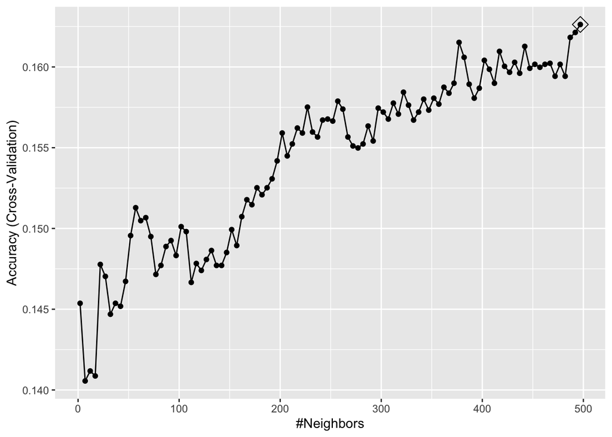

```
## [1] 497
```

Note that while the model’s accuracy seems to increase with larger ks, at k = 500, the training function reports ‘too many ties in knn’. As more neighbors are included into the voting process, the likelihood of ties occurring seems to increase, and in this case, the limit of viable ks seems to be around 500.

The model performs best at 497.

Not very impressive: there are ten different genres, so this model performs a mere 6% above chance.

For comparison, a random forest model will be trained on the train_set.

Fitting random forests weighs heavy on the CPU, so the minimum nodesize is set to 5 (instead of the default of 1) in order to limit computation time somewhat.

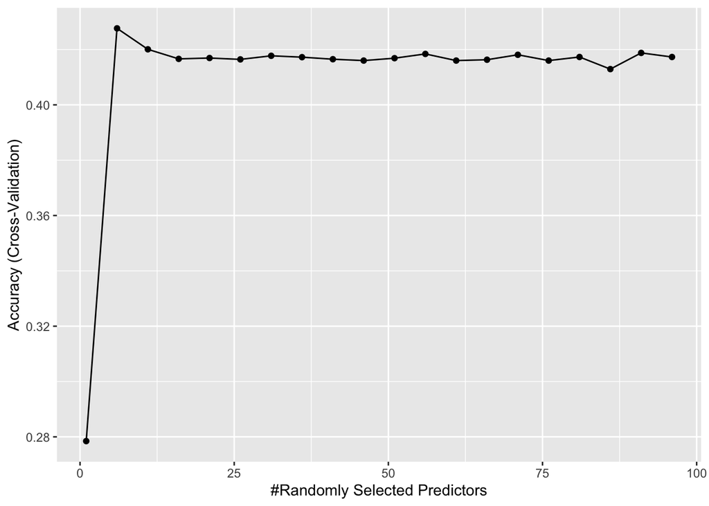

```
## [1] 6
```

### Models with six objective in addition to seven subjective parametes

Here, seven additional ‘subjective’ parameters are included into the model:

- acousticness
- danceability (my favorite predictor!)
- energy
- instrumentalness
- liveness
- speechiness
- valence

The idea is to find out whether including these is worth the trouble, since assessing these parameters would inevitably involve collecting user ratings. This would be much more complicated than just deriving the ‘subjective six’ parameters directly from the music by means of suitable algorithms.

#### knn (13 predictors)

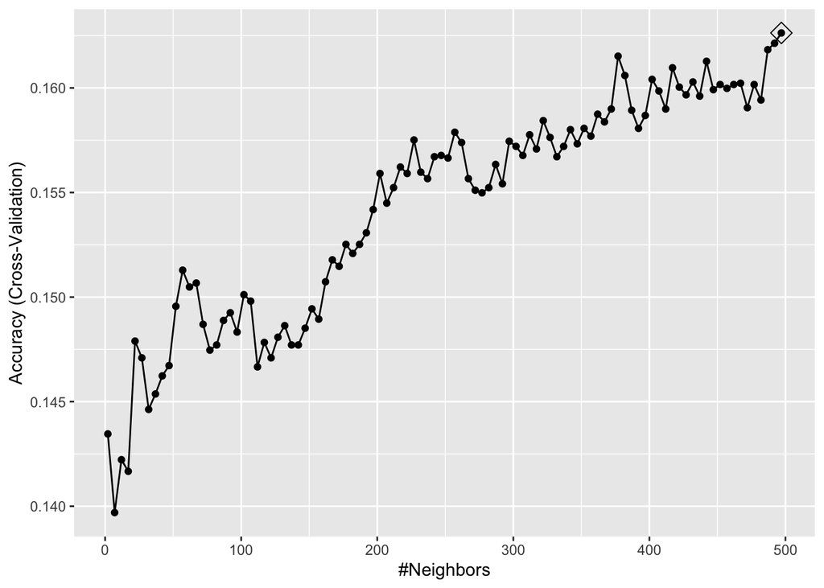

```
## [1] 497
```

Finally, a random forest model with all predictors will be trained on the train_set.

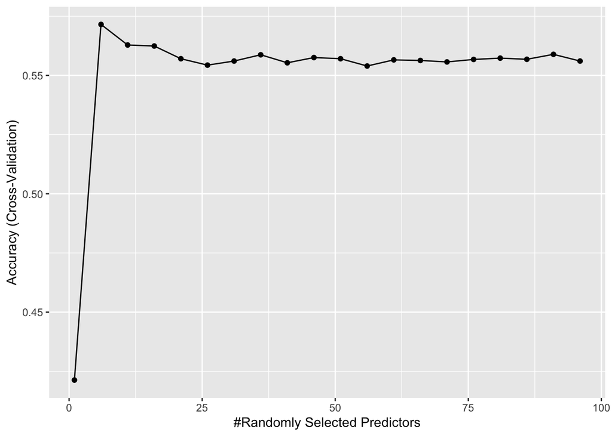

```
## [1] 6
```

## Results

The following tabe summarises the overal accuracies of the four models on the test set:

Model accuracies

[output not shown]

```
## [1] "2022-07-20 16:03:13 CEST"
```

## Conclusion

The aim of this project was to compare two different modeling approaches to predict music genres based on a fairly large dataset with information about songs. The random forest approache was expected to work reasonably well, while the knn model was predicted to suffer from the ‘curse of dimensionality’ with the number of predictors included in the models.

While the knn-approach can be discarded for this problem, a solution based on an optimised random forest model could be a viable path to solving the automatic classification of songs in a music library. Additional effort would be required to optimse the model further, as several modelling parameters were kept constant here in order to allow for practical computation times.